# Getting started with multiLocalFDR

The goal of this document is to get you up and running with `multiLocalFDR` as quickly as possible.

# Installation

```r
library(devtools)
install_github("JungiinChoi/multiLocalFDR")
```

[output not shown]

You can install multiLocalFDR from the Github directory. For Mac users, you need to install Xcode before the installation. (If Xcode is not installed, R automatically redirects you to install XCode.)

```r
library(multiLocalFDR)
```

# Main Functions

## SPMix()

```r
SPMix <- function(z, tol = 5e-6, p_value = FALSE, alternative = "greater", max_iter = 30, mono = TRUE, thre_z = 0.9, Uthre_gam = 0.9, Lthre_gam = 0.01 )
```

- z: Given matrix which column indicates raw data.
- tol: tolerance value for determining convergence of EM-type algorithm
- p-value: if TRUE, than we assume that the input is p-value $\in [0,1]$.
- alternative: if ‘greater’, than it assumes alternative distribution is greater than (on the right side of) null density. This applies for only univariate data.

## plotSPMix()

```r
plotSPMix <- function(z, p0, mu0, sig0, f, f1, localFDR, p_value = FALSE,
                      alternative = "greater", thre_localFDR = 0.2, testing = TRUE,
                      xlab = "x", ylab = "y", coord_legend = c(8, -5, 0.2))
```

- testing: If TRUE, the visualization is for hypothesis testing, otherwise, density estimation.

# Simulations

In this section, we will use **SPMix()** to estimate mixture density and compute local-FDR for generated data. Also, **plotSPMix()** can visualize the fitted results for both univariate and 2-dimensional data.

## required libraries

```r
library(copula)
library(mclust)
library(mvtnorm)
```

```r
library(ggplot2)
library(scatterplot3d)
```

## Univaraite

### Normal + Normal

$$f = 0.8 \cdot N(0,1) + 0.2 \cdot N(3.5, 0.5^2)$$

```r
n=10000
p0=0.8
n0 <- rbinom(1, n, p0)
n1 <- n - n0
z0 <- rnorm(n0)
z1 <- rnorm(n1, mean = 3.5, sd = 0.5)
z_NN1d <- c(z0, z1)

NN1d <- SPMix(z_NN1d, tol = 1e-10, thre_z = 0.99, Uthre_gam = 0.9)
```

```
##    EM iteration: 1 , Change in fdr fit =  1
##    EM iteration: 2 , Change in fdr fit =  0
##    EM iteration: 3 , Change in fdr fit =  0
```

```r
summary(NN1d)
```

```
##          Length Class  Mode
## p0           1  -none- numeric
## mu0          1  -none- numeric
## sig0         1  -none- numeric
## f        10000  -none- numeric
## f1       10000  -none- numeric
## localFDR 10000  -none- numeric
## iter         1  -none- numeric
```

**SPMix()** returns null probability($p0$), null parameters($\mu_0, \sig_0$), estimated density and nonnull density($f, f_1$) and estimated local-FDR value.

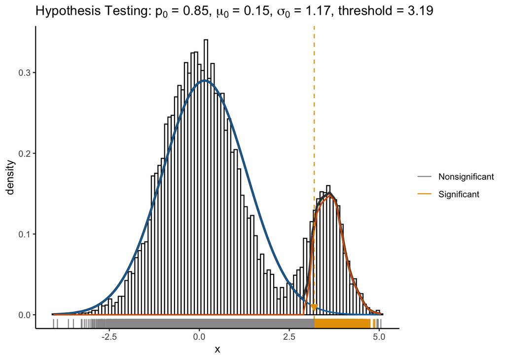

```r
# Hypothesis testing
plotSPMix(z_NN1d, NN1d$p0, NN1d$mu0, NN1d$sig0, NN1d$f, NN1d$f1, NN1d$localFDR)
```

**plotSPMix()** can be used for both hypothesis testing and density estimation. If testing is TRUE (default), it gives density estimation for both normal and nonparametric parts. Also, threshold of given data by given local-FDR threshold is marked with dashed line.

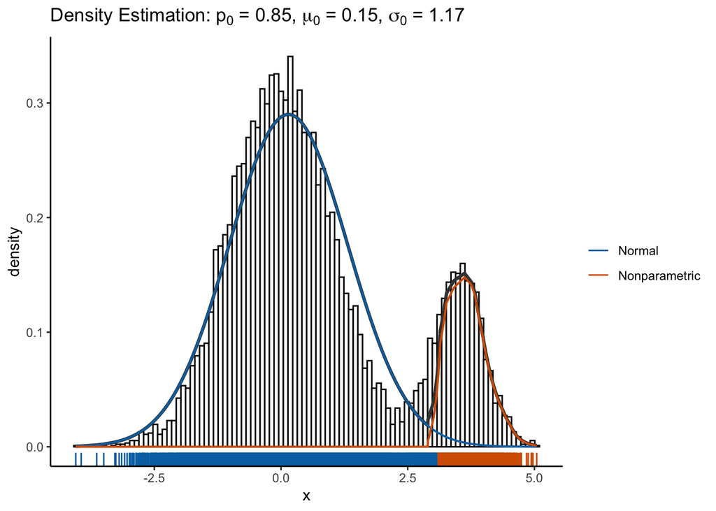

```r
# Density Estimation
plotSPMix(z_NN1d, NN1d$p0, NN1d$mu0, NN1d$sig0, NN1d$f, NN1d$f1, NN1d$localFDR,
          testing = FALSE)
```

If testing is FALSE, it gives density estimation and classifies two parts(normal/nonparametric) by local-FDR value (local-FDR $> 0.5$?).

### Normal + Gamma

What if alternative distribution is not normal?

$$f = 0.8 \cdot N(0,1) + 0.2 \cdot Gamma(shape = 12, rate = 4)$$

```r
z1_gamma <- rgamma(n1, shape = 12, rate = 4)
z_NG1d <- c(z0, z1_gamma)

NG1d <- SPMix(z_NG1d, tol = 1e-10, thre_z = 0.99)
```

```
##    EM iteration: 1 , Change in fdr fit =  0.99992
##    EM iteration: 2 , Change in fdr fit =  8e-05
##    EM iteration: 3 , Change in fdr fit =  0
```

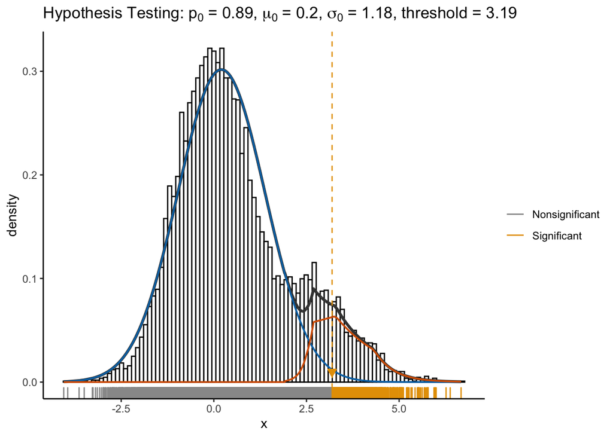

```r
# Hypothesis testing
plotSPMix(z_NG1d, NG1d$p0, NG1d$mu0, NG1d$sig0, NG1d$f, NG1d$f1, NG1d$localFDR)
```

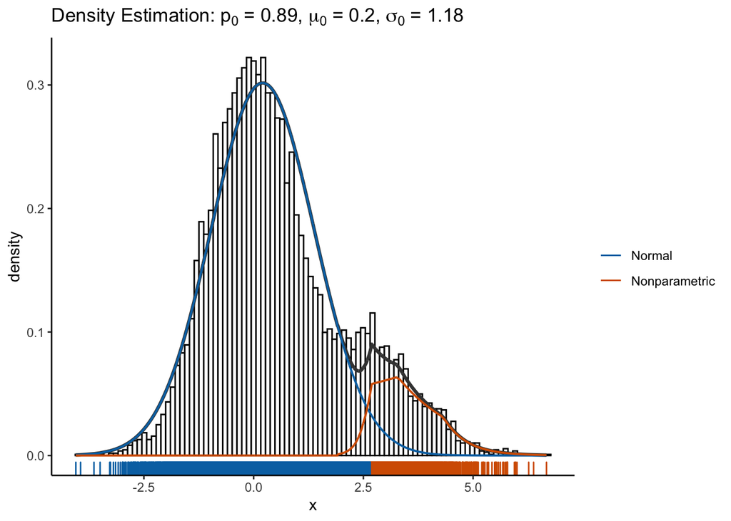

```r
# Density Estimation
plotSPMix(z_NG1d, NG1d$p0, NG1d$mu0, NG1d$sig0, NG1d$f, NG1d$f1, NG1d$localFDR,
          testing = FALSE)
```

## 2-dimensional data

### Normal + Gaussian Copula

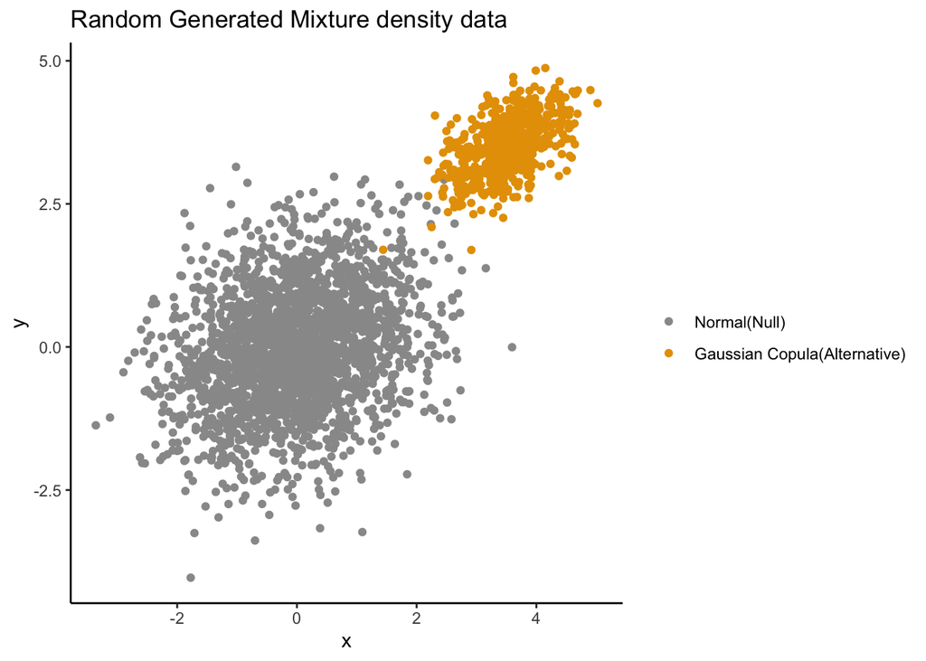

```r
n <- 3000
n0 <- rbinom(1, n, p0)
n1 <- n - n0
sig0 <- matrix(c(1, 0.25, 0.25, 1), ncol = 2, byrow = T)
V <- rCopula(n1, ellipCopula(family = "normal", param = 0.5, dim = 2))
z0 <- rmvnorm(n0, sigma = sig0)
z1 <- qnorm(V, mean = 3.5, sd = .5)
z_NN2d <- data.frame(rbind(z0, z1))

ggplot(z_NN2d, aes(x = z_NN2d[,1], y = z_NN2d[,2])) +
  geom_point(aes(color = factor(c(rep(1,n0), rep(2,n1)), labels = c("Normal(Null)", "Gaussian Copula(Alternative)")))) +
  scale_color_manual(values = c("#999999", "#E69F00"), name="")  +
  labs(title = "Random Generated Mixture density data", x="x", y = "y") +
  theme_classic()
```

```r
NN2d <- SPMix(z_NN2d, tol = 1e-10)
```

```
##    EM iteration: 1 , Change in mdfdr fit =  0.87565
##    EM iteration: 2 , Change in mdfdr fit =  0.03219
##    EM iteration: 3 , Change in mdfdr fit =  0.09216
##    EM iteration: 4 , Change in mdfdr fit =  0
```

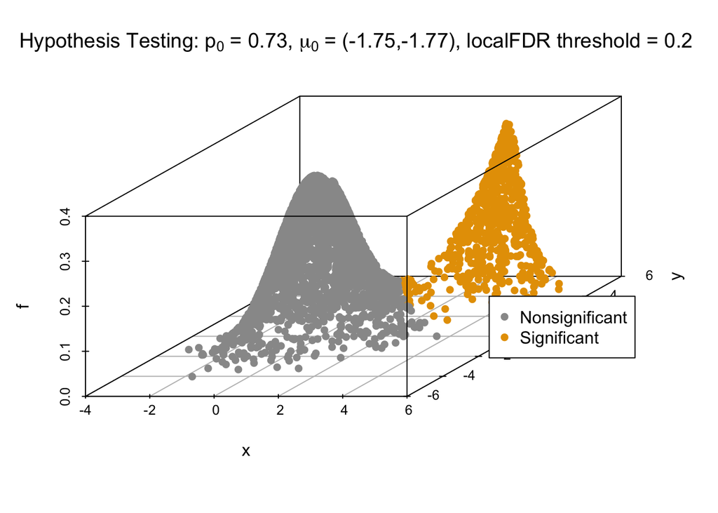

```r
plotSPMix(z_NN2d, NN2d$p0, NN2d$mu0, NN2d$sig0, NN2d$f, NN2d$f1, NN2d$localFDR,
          xlab = "x", ylab = "y")
```

**plotSPMix()** also provides visualization of 2-dimensional data. You can set name for x-axis and y-axis using **xlab**, **ylab**.

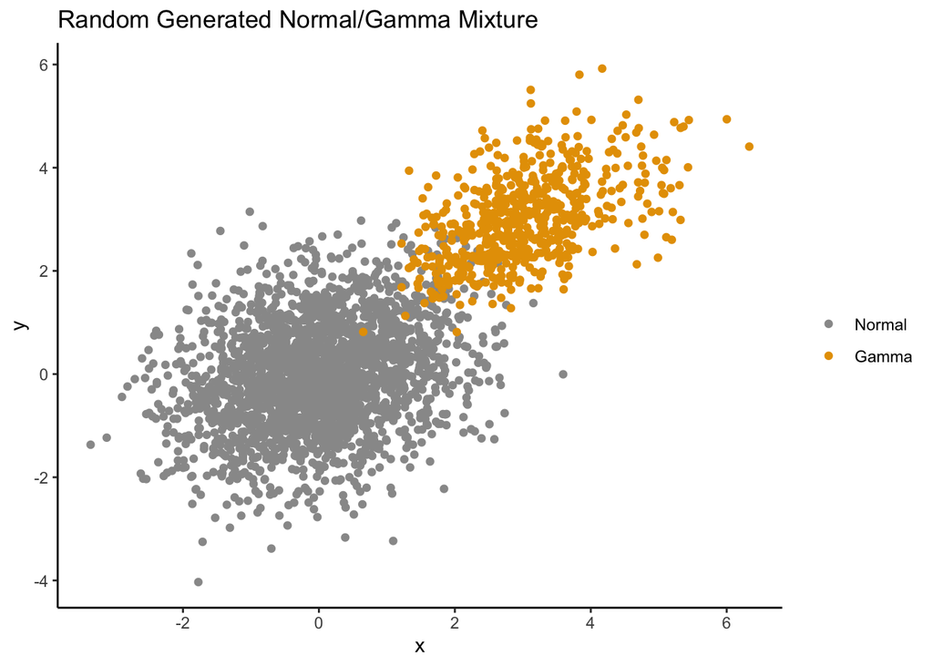

```r
z1_gamma <- qgamma(V, shape = 12, rate = 4)
z_NG <- data.frame(rbind(z0, z1_gamma))

ggplot(z_NG, aes(x = z_NG[,1], y = z_NG[,2])) +
  geom_point(aes(color = factor(c(rep(1,n0), rep(2,n1)), labels = c("Normal", "Gamma")))) +
  scale_color_manual(values = c("#999999", "#E69F00"), name="")  +
  labs(title = "Random Generated Normal/Gamma Mixture", x="x", y = "y") +
  theme_classic()
```

```r
NG <- SPMix(z_NG, tol = 1e-10)
```

```
##    EM iteration: 1 , Change in mdfdr fit =  0.84776
##    EM iteration: 2 , Change in mdfdr fit =  0.01875
##    EM iteration: 3 , Change in mdfdr fit =  0.01466
##    EM iteration: 4 , Change in mdfdr fit =  0.01081
##    EM iteration: 5 , Change in mdfdr fit =  0.01366
##    EM iteration: 6 , Change in mdfdr fit =  0.09435
##    EM iteration: 7 , Change in mdfdr fit =  0
```

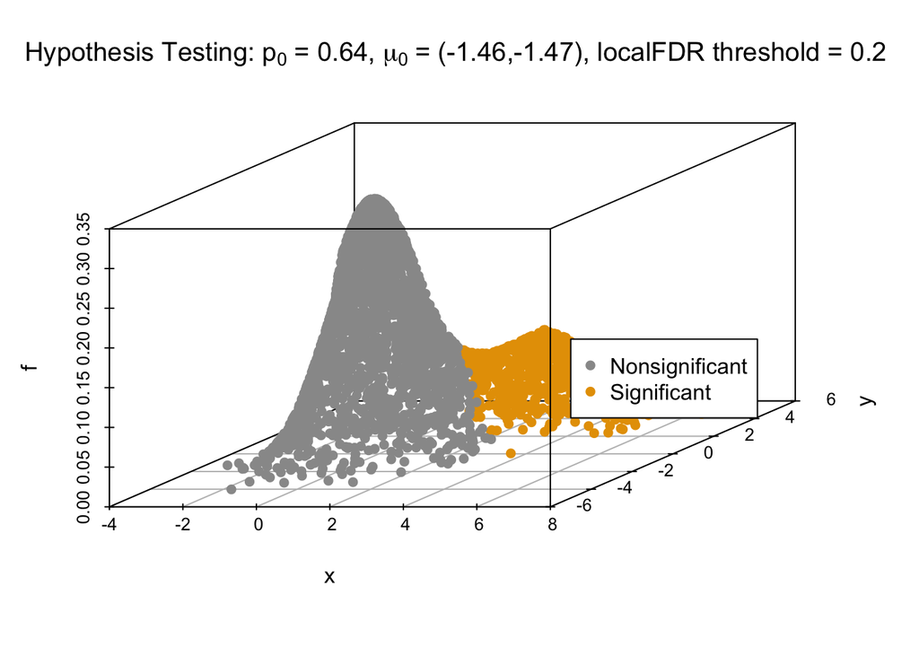

```r
plotSPMix(z_NG, NG$p0, NG$mu0, NG$sig0, NG$f, NG$f1, NG$localFDR,
          xlab = "x", ylab = "y")
```

## 3-dimensional data

### Normal + Gaussian Copula

Let’s consider null distribution and multivariate normal density and nonnull distribution as Gaussian copula with marginal normal distribution.

```r
library(scatterplot3d)

Sigma0 <- matrix(c(1, 0.25, 0.25, 0.25, 1, 0.25, 0.25,0.25,1), ncol = 3)
n0 <- rbinom(1, n, p0)
n1 <- n - n0
V <- rCopula(n1, ellipCopula(family = "normal", param = 0.5, dim = 3))
z0_NN3d <- rmvnorm(n0, sigma = Sigma0)
z1_NN3d <- qnorm(V, mean = 3.5, sd = .5)
z_NN3d <- rbind(z0_NN3d, z1_NN3d)

NN3d <- SPMix(z_NN3d, 1e-10)
```

```
##    EM iteration: 1 , Change in mdfdr fit =  0.89533
##    EM iteration: 2 , Change in mdfdr fit =  0.08171
##    EM iteration: 3 , Change in mdfdr fit =  0.02296
##    EM iteration: 4 , Change in mdfdr fit =  0
```

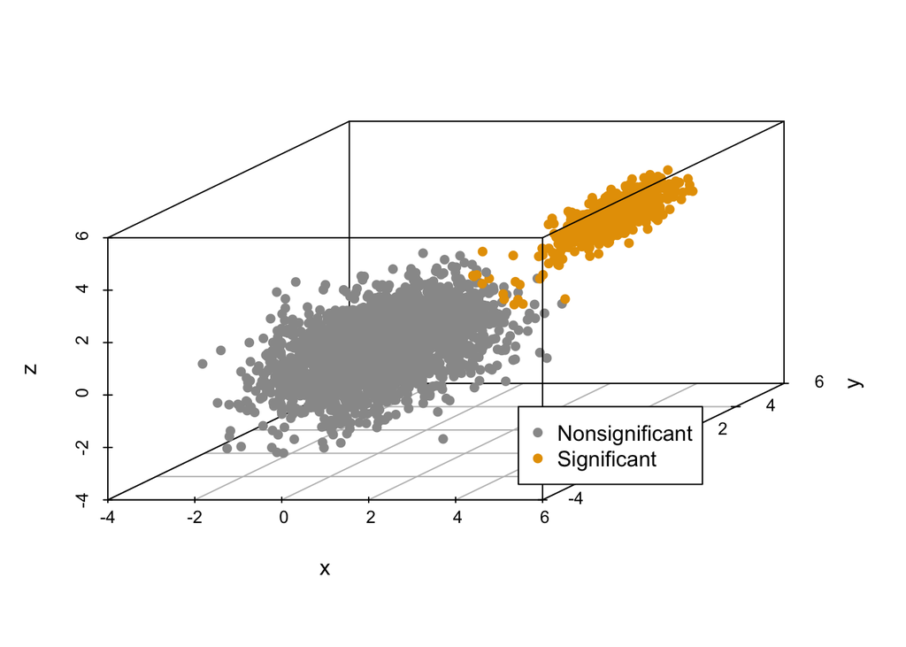

```r
colors <- c("#999999", "#E69F00")
colors <- colors[as.numeric(NN3d$localFDR <= 0.1)+1]
scatterplot_NN<- scatterplot3d(z_NN3d, pch = 16, color=colors,
                            xlab = "x", ylab = "y", zlab = "z")
legend_pathway <- factor((NN3d$localFDR <= 0.1), levels = c(FALSE, TRUE),
                         labels = c("Nonsignificant", "Significant"))
legend(scatterplot_NN$xyz.convert(6, -5, 0), legend = levels(legend_pathway),
       col = c("#999999", "#E69F00"), pch = 16)
```

Orange dots are given data with lower local-FDR (localFDR $< 0.1$).

### Normal + Frank Copula

```r
library(scatterplot3d)

V_NG <- rCopula(n1, frankCopula(param = 0.5, dim = 3))
z0_NG3d <- rmvnorm(n0, sigma = Sigma0)
z1_NG3d <- qgamma(V_NG, shape = 12, rate = 4)
z_NG3d <- rbind(z0_NG3d, z1_NG3d)

NG3d <- SPMix(z_NG3d, 1e-10)
```

```
##    EM iteration: 1 , Change in mdfdr fit =  0.17678
##    EM iteration: 2 , Change in mdfdr fit =  0.07137
##    EM iteration: 3 , Change in mdfdr fit =  0.03571
##    EM iteration: 4 , Change in mdfdr fit =  0.02378
##    EM iteration: 5 , Change in mdfdr fit =  0.02952
##    EM iteration: 6 , Change in mdfdr fit =  0.02179
##    EM iteration: 7 , Change in mdfdr fit =  0.02301
##    EM iteration: 8 , Change in mdfdr fit =  0.01988
##    EM iteration: 9 , Change in mdfdr fit =  0.02605
##    EM iteration: 10 , Change in mdfdr fit =  0.03786
##    EM iteration: 11 , Change in mdfdr fit =  0.04676
##    EM iteration: 12 , Change in mdfdr fit =  0.06776
##    EM iteration: 13 , Change in mdfdr fit =  0.08064
##    EM iteration: 14 , Change in mdfdr fit =  0.09141
##    EM iteration: 15 , Change in mdfdr fit =  0.06539
##    EM iteration: 16 , Change in mdfdr fit =  0.06103
##    EM iteration: 17 , Change in mdfdr fit =  0.05631
##    EM iteration: 18 , Change in mdfdr fit =  0.06493
##    EM iteration: 19 , Change in mdfdr fit =  0
```

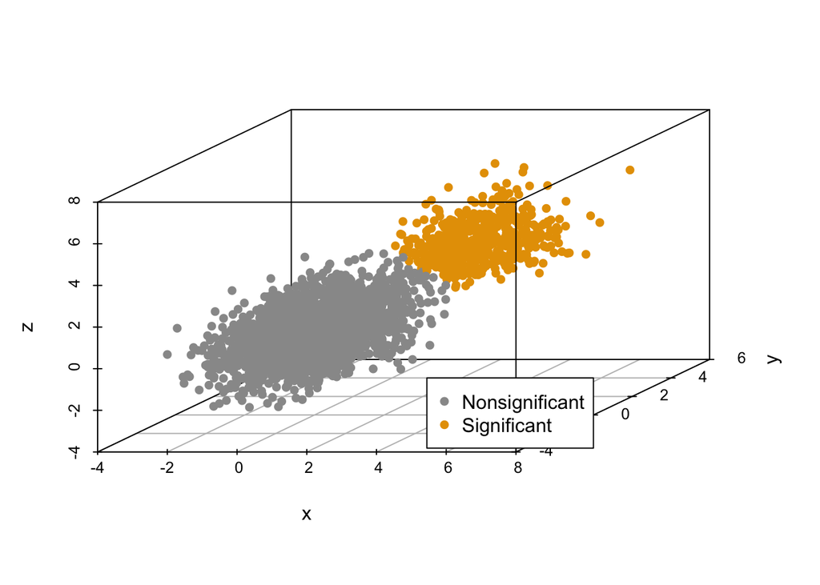

```r
colors <- c("#999999", "#E69F00")
colors <- colors[as.numeric(NG3d$localFDR <= 0.1)+1]
scatterplot_NG<- scatterplot3d(z_NG3d, pch = 16, color=colors,
                            xlab = "x", ylab = "y", zlab = "z")
legend_pathway <- factor((NG3d$localFDR <= 0.2), levels = c(FALSE, TRUE),
                         labels = c("Nonsignificant", "Significant"))
legend(scatterplot_NG$xyz.convert(6, -5, 0), legend = levels(legend_pathway),
       col = c("#999999", "#E69F00"), pch = 16)
```

# Applications

## Galaxy Velocity (Univariate)

Internal data ‘galaxy’ is a data frame including radial velocities of globular clusters of M104 and Milky Way stars. It’s known that Milky Way stars have much lower radial velocities.

```r
data("galaxy", package = "multiLocalFDR")
head(galaxy)
```

```
##      radius  velocity
## 1  9.900000 1034.0669
## 2 20.129999 1013.8658
## 3 12.640000 1055.4016
## 4 12.160000  776.8124
## 5  9.979999 1606.6024
## 6 11.490000  774.1326
```

```r
z_galaxy <- galaxy$velocity
params <- SPMix(z_galaxy, alternative = "less")
```

```
##    EM iteration: 1 , Change in fdr fit =  0.95717
##    EM iteration: 2 , Change in fdr fit =  0.04283
##    EM iteration: 3 , Change in fdr fit =  0
```

- z_galaxy: input data does not have to be z-values or p-values.
- alternative = “less”: we know that velocities of M104 are much faster and follow Normal density.

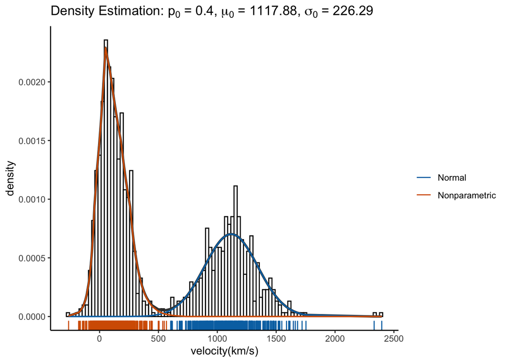

```r
plotSPMix(z_galaxy, params$p0, params$mu0, params$sig0, params$f, params$f1,
          params$localFDR, alternative = "greater", testing = FALSE,
                      xlab = "velocity(km/s)")
```

## Pathways (Multivariate)

Internal data ‘pathways’ is a list of significantly upregulated genes in three published studies: (1) peripheral leukocytes(L), (2) orbital inflammatory disease(O), and (3) sinus brushings(S) compared to healthy controls.

```r
data("pathways", package = "multiLocalFDR")
head(pathways)
```

```
##                             Gene.Set        L         O         S
## 1        Neutrophil degranulation(R) 3.14e-13 3.280e-09 1.110e-16
## 2          Antimicrobial peptides(R) 7.69e-06 1.140e-03 1.310e-03
## 3    Toll-Like Receptors Cascades(R) 1.85e-05 3.390e-03 2.780e-04
## 4       Signaling by Interleukins(R) 8.91e-05 1.880e-05 8.240e-08
## 5 Fructose and mannose metabolism(K) 4.21e-04 2.865e-01 4.490e-01
## 6   IL4-mediated signaling events(N) 5.47e-04 5.040e-04 1.065e-01
```

### Univariate analysis

```r
## SpMix for each pathway
params_L <- SPMix(pathways[,2], p_value = TRUE, tol = 1e-10)
```

```
##    EM iteration: 1 , Change in fdr fit =  0
##    EM iteration: 2 , Change in fdr fit =  0
##    EM iteration: 3 , Change in fdr fit =  0
##    EM iteration: 4 , Change in fdr fit =  0
##    EM iteration: 5 , Change in fdr fit =  0
##    EM iteration: 6 , Change in fdr fit =  0
##    EM iteration: 7 , Change in fdr fit =  0
```

```r
params_O <- SPMix(pathways[,3], p_value = TRUE, tol = 1e-10)
```

```
##    EM iteration: 1 , Change in fdr fit =  0.00095
##    EM iteration: 2 , Change in fdr fit =  0.00092
##    EM iteration: 3 , Change in fdr fit =  0
##    EM iteration: 4 , Change in fdr fit =  0
##    EM iteration: 5 , Change in fdr fit =  0
##    EM iteration: 6 , Change in fdr fit =  0
##    EM iteration: 7 , Change in fdr fit =  0
##    EM iteration: 8 , Change in fdr fit =  0
##    EM iteration: 9 , Change in fdr fit =  0
##    EM iteration: 10 , Change in fdr fit =  0
##    EM iteration: 11 , Change in fdr fit =  0
##    EM iteration: 12 , Change in fdr fit =  0
##    EM iteration: 13 , Change in fdr fit =  0
##    EM iteration: 14 , Change in fdr fit =  0
##    EM iteration: 15 , Change in fdr fit =  0
##    EM iteration: 16 , Change in fdr fit =  0
##    EM iteration: 17 , Change in fdr fit =  0
##    EM iteration: 18 , Change in fdr fit =  0
##    EM iteration: 19 , Change in fdr fit =  0
##    EM iteration: 20 , Change in fdr fit =  0
##    EM iteration: 21 , Change in fdr fit =  0
##    EM iteration: 22 , Change in fdr fit =  0
##    EM iteration: 23 , Change in fdr fit =  0
##    EM iteration: 24 , Change in fdr fit =  0
##    EM iteration: 25 , Change in fdr fit =  0
##    EM iteration: 26 , Change in fdr fit =  0
##    EM iteration: 27 , Change in fdr fit =  0
##    EM iteration: 28 , Change in fdr fit =  0
##    EM iteration: 29 , Change in fdr fit =  0
##    EM iteration: 30 , Change in fdr fit =  0
```

```r
params_S <- SPMix(pathways[,4], p_value = TRUE, tol = 1e-10)
```

```
##    EM iteration: 1 , Change in fdr fit =  0
##    EM iteration: 2 , Change in fdr fit =  0
##    EM iteration: 3 , Change in fdr fit =  0
##    EM iteration: 4 , Change in fdr fit =  0
##    EM iteration: 5 , Change in fdr fit =  0
##    EM iteration: 6 , Change in fdr fit =  0
##    EM iteration: 7 , Change in fdr fit =  0
##    EM iteration: 8 , Change in fdr fit =  0
##    EM iteration: 9 , Change in fdr fit =  0
##    EM iteration: 10 , Change in fdr fit =  0
##    EM iteration: 11 , Change in fdr fit =  0
##    EM iteration: 12 , Change in fdr fit =  0
##    EM iteration: 13 , Change in fdr fit =  0
##    EM iteration: 14 , Change in fdr fit =  0
##    EM iteration: 15 , Change in fdr fit =  0
##    EM iteration: 16 , Change in fdr fit =  0
##    EM iteration: 17 , Change in fdr fit =  0
##    EM iteration: 18 , Change in fdr fit =  0
##    EM iteration: 19 , Change in fdr fit =  0
##    EM iteration: 20 , Change in fdr fit =  0
##    EM iteration: 21 , Change in fdr fit =  0
##    EM iteration: 22 , Change in fdr fit =  0
##    EM iteration: 23 , Change in fdr fit =  0
##    EM iteration: 24 , Change in fdr fit =  0
##    EM iteration: 25 , Change in fdr fit =  0
##    EM iteration: 26 , Change in fdr fit =  0
##    EM iteration: 27 , Change in fdr fit =  0
##    EM iteration: 28 , Change in fdr fit =  0
##    EM iteration: 29 , Change in fdr fit =  0
##    EM iteration: 30 , Change in fdr fit =  0
```

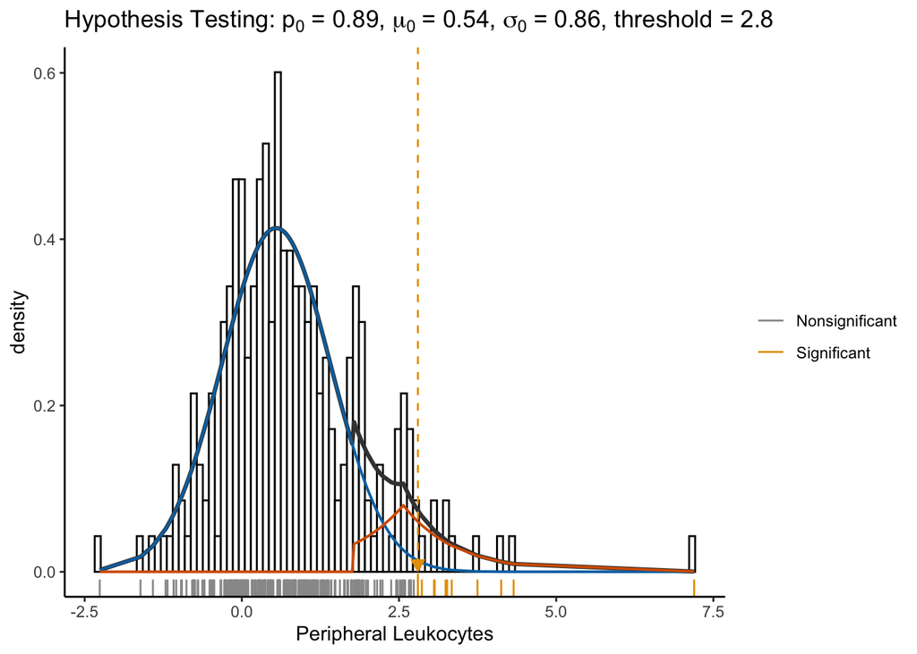

```r
## Plot results for each pathway
plotSPMix(pathways[,2], params_L$p0, params_L$mu0, params_L$sig0, params_L$f,
          params_L$f1, params_L$localFDR, p_value = TRUE, xlab = "Peripheral Leukocytes")
```

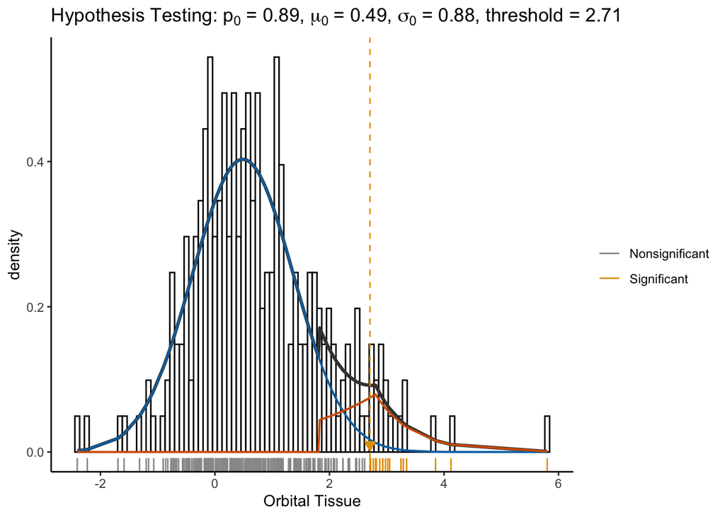

```r
plotSPMix(pathways[,3], params_O$p0, params_O$mu0, params_O$sig0, params_O$f,
          params_O$f1, params_O$localFDR, p_value = TRUE, xlab = "Orbital Tissue")
```

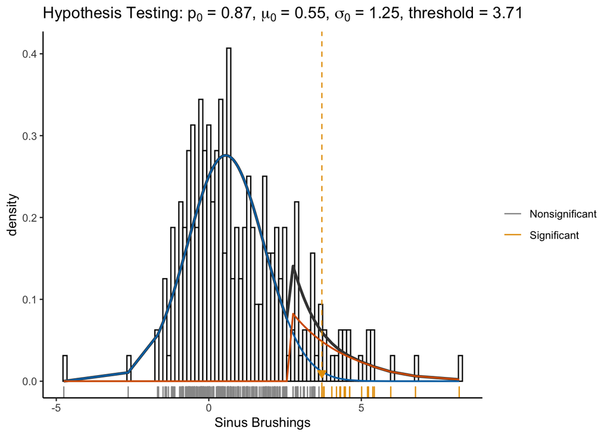

```r
plotSPMix(pathways[,4], params_S$p0, params_S$mu0, params_S$sig0, params_S$f,
          params_S$f1, params_S$localFDR, p_value = TRUE, xlab = "Sinus Brushings")
```

### Multivariate Analysis

```r
## SpMix for 3-dimensional data
params_LOS <- SPMix(pathways[,2:4], p_value = TRUE, tol = 1e-10)
```

```
##    EM iteration: 1 , Change in mdfdr fit =  0
##    EM iteration: 2 , Change in mdfdr fit =  0
##    EM iteration: 3 , Change in mdfdr fit =  0
```

```r
## Pathways which md-fdr <= 0.01
head(pathways[params_LOS$localFDR <= 0.01,]$Gene.Set)
```

```
## [1] "Neutrophil degranulation(R)"      "Antimicrobial peptides(R)"
## [3] "Toll-Like Receptors Cascades(R)"  "Signaling by Interleukins(R)"
## [5] "IL4-mediated signaling events(N)" "Amoebiasis(K)"
```

```r
length(pathways[params_LOS$localFDR <= 0.01,]$Gene.Set)
```

```
## [1] 26
```

```r
# md-fdr dataframe
pathways_df <- pathways
pathways_df$localFDR <- params_LOS$localFDR
pathways_df$sgnf <- (params_LOS$localFDR <= 0.01)
head(pathways_df)
```

```
##                             Gene.Set        L         O         S     localFDR
## 1        Neutrophil degranulation(R) 3.14e-13 3.280e-09 1.110e-16 9.983243e-18
## 2          Antimicrobial peptides(R) 7.69e-06 1.140e-03 1.310e-03 4.873614e-04
## 3    Toll-Like Receptors Cascades(R) 1.85e-05 3.390e-03 2.780e-04 9.196950e-04
## 4       Signaling by Interleukins(R) 8.91e-05 1.880e-05 8.240e-08 2.653760e-06
## 5 Fructose and mannose metabolism(K) 4.21e-04 2.865e-01 4.490e-01 4.147595e-02
## 6   IL4-mediated signaling events(N) 5.47e-04 5.040e-04 1.065e-01 2.505199e-03
##    sgnf
## 1  TRUE
## 2  TRUE
## 3  TRUE
## 4  TRUE
## 5 FALSE
## 6  TRUE
```

### 3d scatter plot

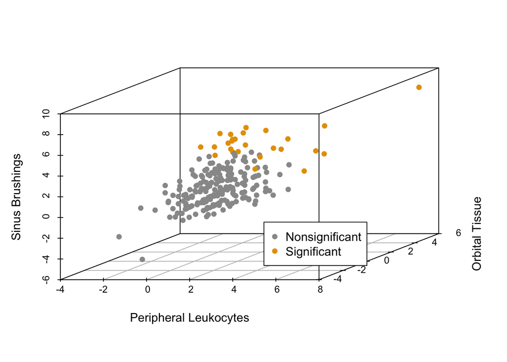

```r
colors <- c("#999999", "#E69F00")
colors <- colors[as.numeric(pathways_df$sgnf)+1]
scatterplot<- scatterplot3d(qnorm(1-as.matrix(pathways_df[,2:4])), pch = 16, color=colors,
              xlab = "Peripheral Leukocytes",
              ylab = "Orbital Tissue",
              zlab = "Sinus Brushings")

legend_pathway <- factor(pathways_df$sgnf, levels = c(FALSE, TRUE), labels = c("Nonsignificant", "Significant"))
legend(scatterplot$xyz.convert(6, -5, 0), legend = levels(legend_pathway),
       col = c("#999999", "#E69F00"), pch = 16)
```

Orange dots are pathways with md-fdr $< 0.01$.